# Information Architecture and User Experience

KOMC37: Project Management  
in Digital Environments 2026

nils.holmberg@iko.lu.se

## Lecture literature

[figure not shown]

Ding et al. (2025)

[figure not shown]

Ebook downloaded from:  
[https://webflow.com/](https://cca-cce.github.io/osm-comm/res/edu/komc37/Webflow_Ebook_TheModernWebDesignProcess.pdf)

## Digital production

#### Workshop, dec 2 (zoom?)

- Session 1: Define Need and Prototype
  - Define the user situation — 10 minutes.
  - Sketch the user’s journey — 10 minutes.
  - Build a simple prototype — 25 minutes.
- Session 2: Test, Interpret and Improve
  - Prepare the test — 5 minutes.
  - Test with another group — 20 minutes.
  - Interpret and revise — 15 minutes.

#### Supervision, dec 9 (zoom?)

- Information architecture
- User experience
- User interface
- Digital production, prototype
- Project integration

## Project cases

[figure not shown]

[figure not shown]

[figure not shown]

[figure not shown]

[figure not shown]

## AI use in academic work

- OK: brainstorm ideas, do research
- OK: generate project materials
- OK: data analysis, statistics tools
- OK: be transparent with your prompts
- Not OK: copy-paste text to your exam
- Not OK: generate fake empirical data
- Not OK: upload content you dont own
- Not OK: upload data with personal info
- https://gemini.google.com/

## Web development

- Strategy
- Scope
- Structure
- Skeleton
- Surface

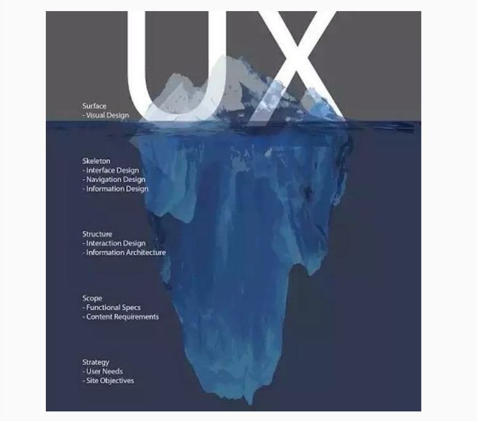

# Chapter 1

Information Architecture and UX Design: Definitions and Scope

## Information architecture and UX

- **IA:** organize information so people find, understand, and use it.
- **UX:** the whole interaction, including expectations, feelings, and outcomes.
- Structure and interaction jointly support the user’s goal.
- Coordinate content, navigation, interface, and visual design.

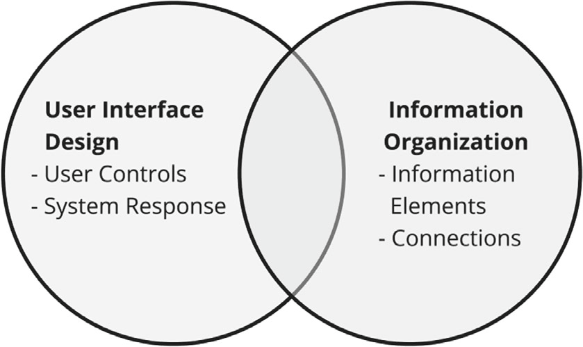

## Information spaces

- Information spaces connect content, people, and tools.
- Include websites, apps, and physical touchpoints.
- Users pursue goals across channel boundaries.
- **Example:** job posting → website → on-site interview.

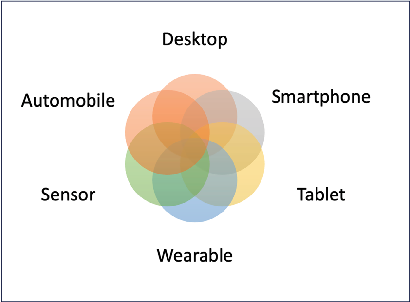

## Relevance to strategic communication

- Start with user goals and organizational outcomes.
- Translate communication problems into findable tasks.
- **Example:** recruits cannot locate clear job requirements.
- Improve labels, role pages, and application steps.

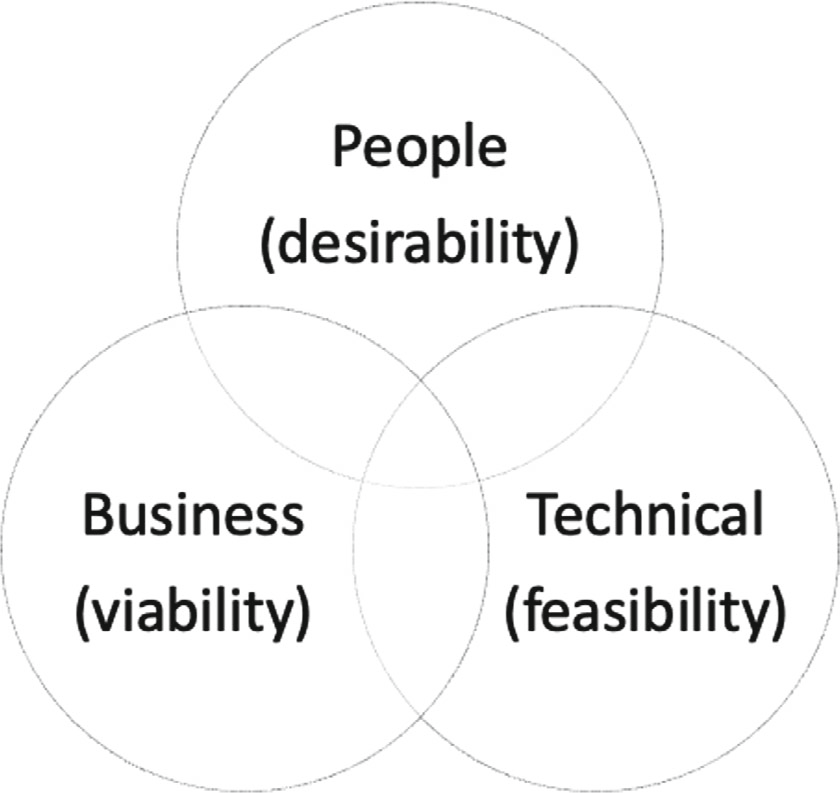

# Chapter 3

Human-Centered Design

## Human-centered design

- Begin with people, their goals, and context of use.
- Study capabilities, constraints, and accessibility needs.
- Balance human needs with business and technical realities.
- **Website:** Test the size guide with shoppers of different abilities.

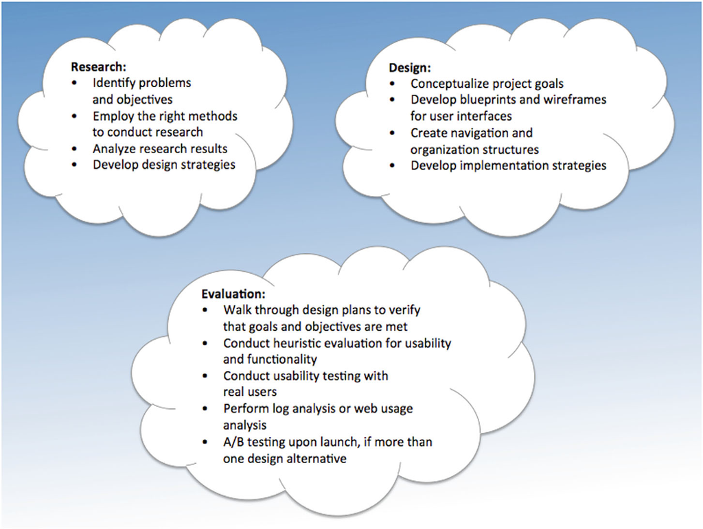

## User needs and organizational goals

- Balance user needs, business value, and technical feasibility.
- Treat client requests as assumptions to investigate.
- **Example:** cheaper self-service versus access to live help.
- **Intranet:** Balance a standard introduction with company-specific employee needs.

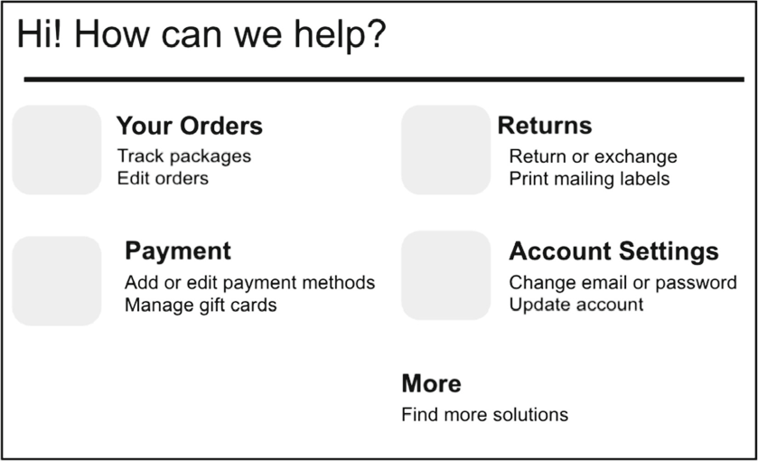

## User involvement

- Research with users to uncover goals and constraints.
- Co-design to explore ideas and alternative workflows.
- Test prototypes with representative user groups.
- **Intranet:** Involve newly acquired employees when revising onboarding slides.

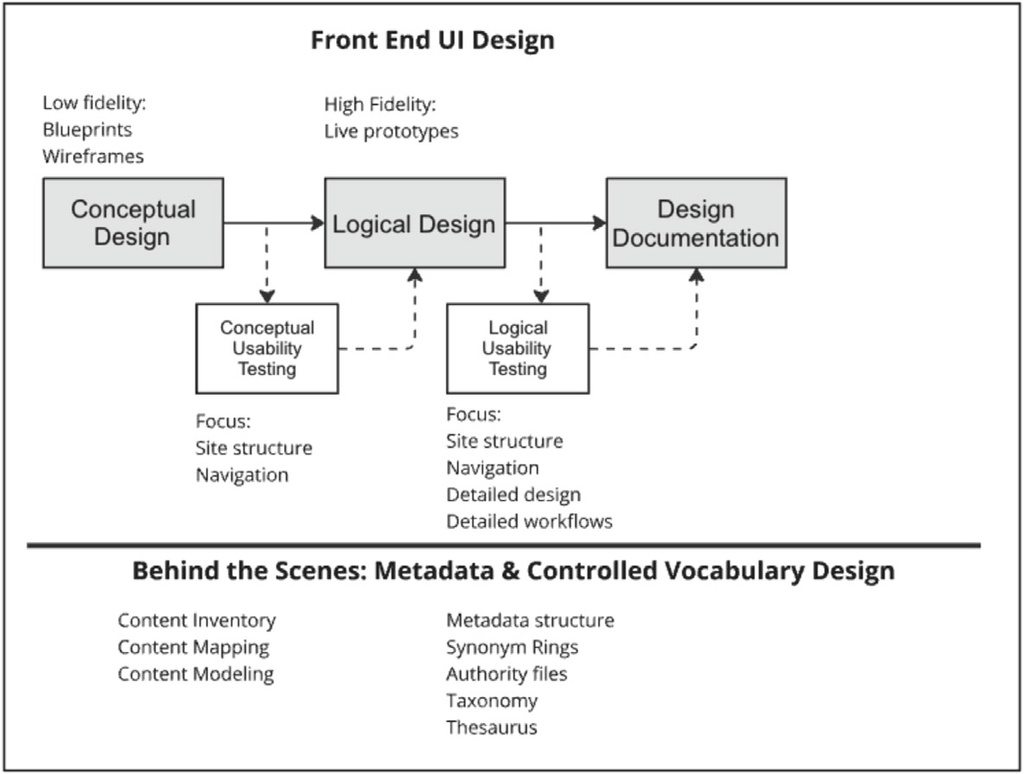

## Iterative design

- Prototype → test → interpret → refine → retest.
- Begin with low-fidelity screens and concrete tasks.
- Observe where users hesitate, fail, or misunderstand.
- **Website:** Test whether a proposed landing page clarifies job expectations.

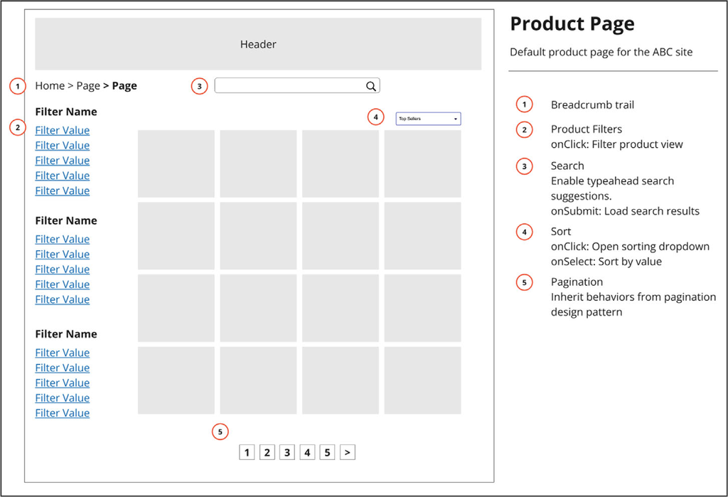

# Chapter 4

Research and Evaluation

## Research and evaluation

- Before prototyping: investigate context, content, and users.
- Identify goals, current tasks, and information gaps.
- After prototyping: evaluate realistic tasks and requirements.
- **Intranet:** Survey onboarding needs, then test the revised introduction.

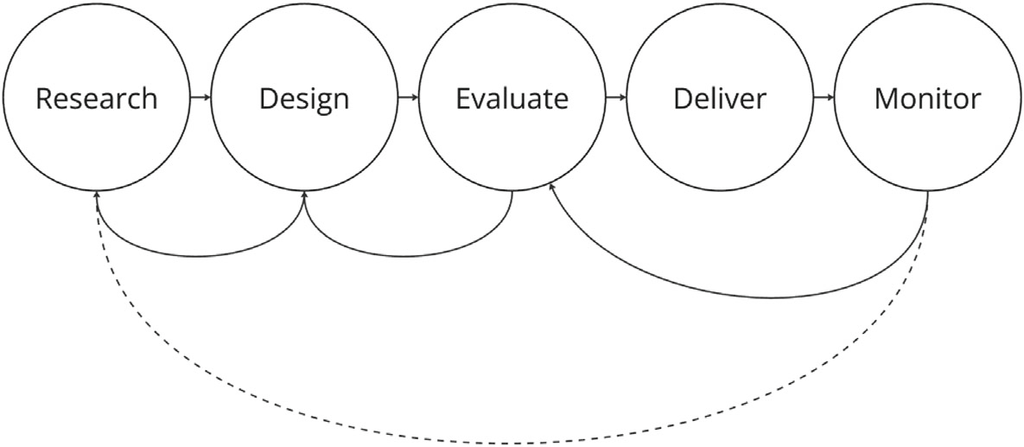

## Selecting methods

- Use interviews for motives, context, and follow-up questions.
- Use surveys for patterns across more respondents.
- **Social media:** Compare interviews and surveys for evaluating campaign appeal.

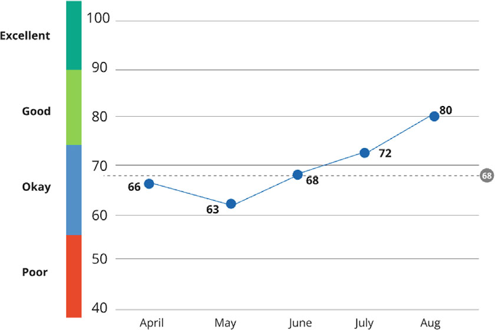

## Evaluating usability

- **Heuristics:** experts inspect against usability principles.
- Review independently; combine issues and severity ratings.
- **User tests:** observe representative people completing tasks.
- **Website:** Ask buyers to find product and sustainability information.

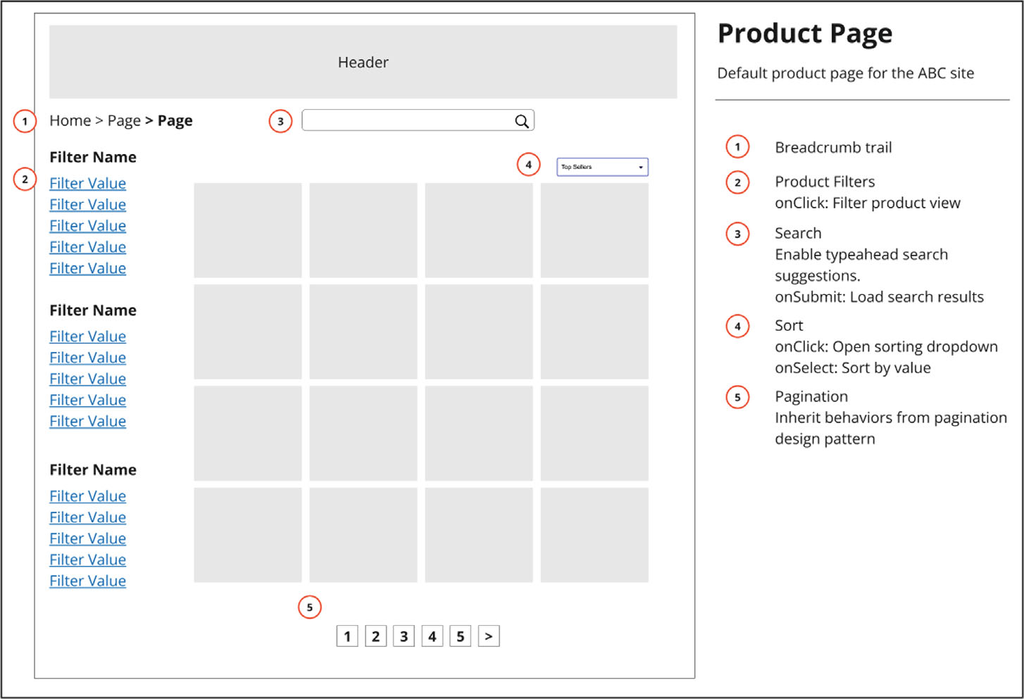

## Card sorting

- Sort content cards to reveal users’ mental models.
- **Open sort:** participants create and name groups.
- **Closed sort:** participants use predefined categories.
- **Intranet:** Have employees group onboarding topics before revising the presentation.

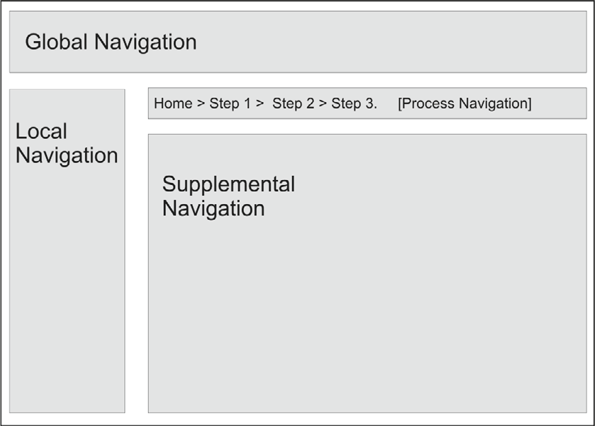

## Personas and user journeys

- **Personas:** research-based goals and behavior patterns.
- **Journeys:** actions, touchpoints, emotions, and barriers over time.
- Build both from interviews, observation, and other evidence.
- **Social media:** Map an applicant’s journey from LinkedIn to applying.

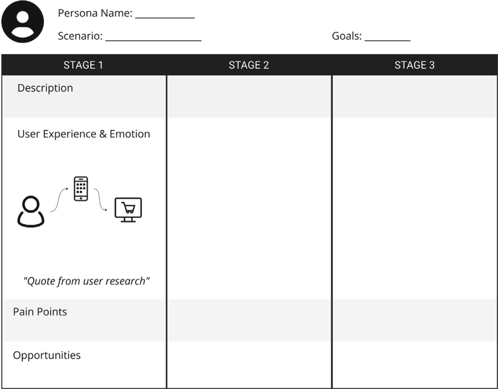

# Chapter 5

Information Organization and Navigation Design

- `How is this implemented in client organization?`

## Organizing information

- **Logical organization:** explicit ordering rules.
- Examples: alphabet, date, price, or location.
- **Semantic organization:** relationships based on meaning.
- **Website:** Compare product-name lists with application-based product categories.

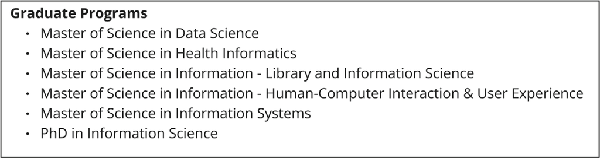

## Metadata and consistent terminology

- **Metadata:** descriptions of content, context, and relationships.
- Use consistent fields: title, subject, owner, and date.
- **Controlled vocabularies:** preferred terms and synonym relationships.
- **Intranet:** Standardize department names.

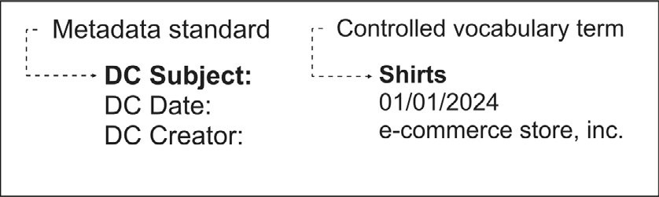

## Taxonomies and tagging

- **Taxonomies:** structured broader–narrower category.
- **Facets:** combine independent attributes, size and brand.
- **Tags:** user language, with ambiguity and duplicates to manage.
- **Website:** Filter pants by length, size, and fit preferences.

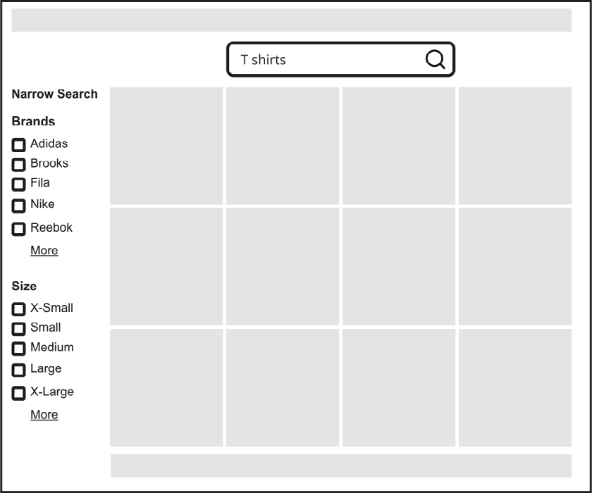

## Navigation and search

- Navigation supports orientation, browsing, and related topics.
- Search supports targeted queries and known items.
- **Known product:** offer search, synonyms, and clear results.
- **Website:** Connect the proposed campaign page, job ad, and application form.

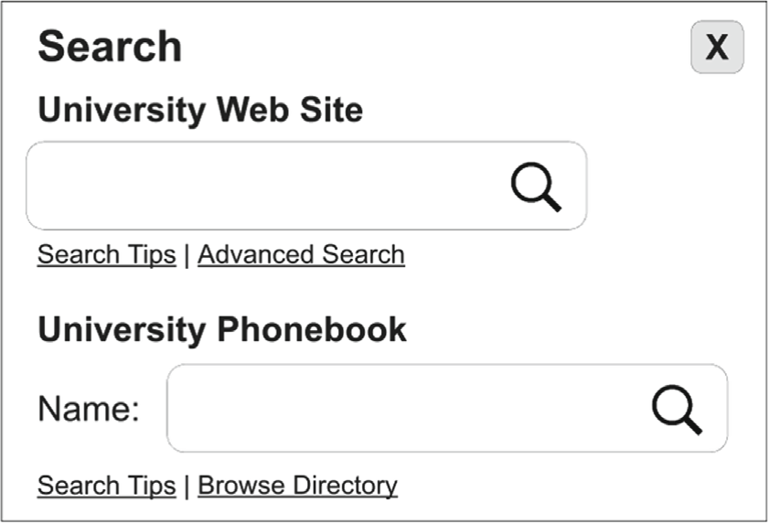

# Chapter 6

Human Information Behavior and Design Implications

## Information behavior and design

- Study how people seek, encounter, and use information.
- Needs vary with experience, context, and constraints.
- Combine project research with behavioral theories.
- **Intranet:** Study where new employees look for help during onboarding.

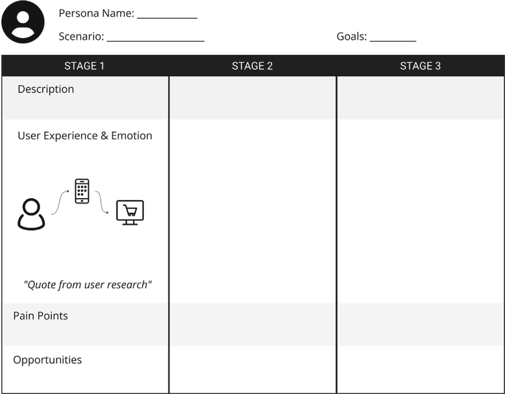

## Changing information needs

- **Berry picking:** gather useful pieces across different sources.
- New information changes the query and direction.
- **Exploratory search:** learn through searching and browsing over time.
- **Social media:** Connect winter activity posts with related beginner-friendly outdoor tips.

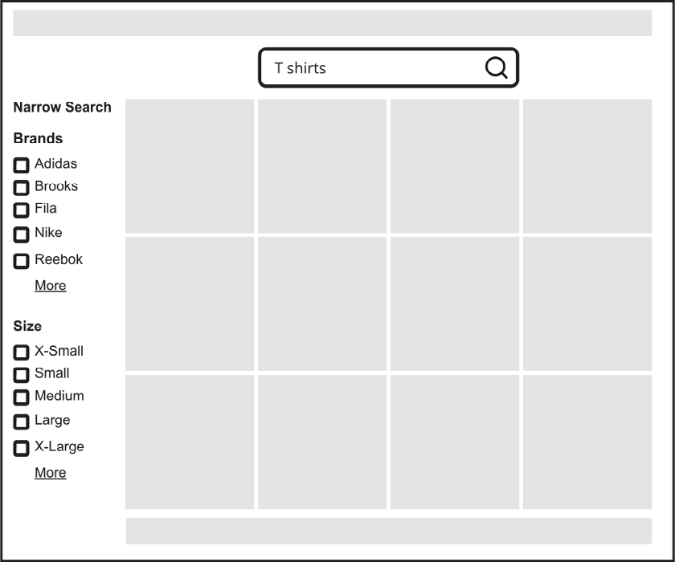

## Bounded rationality

- **Bounded rationality:** limited time, information, and cognitive capacity.
- **Satisficing:** accept the first sufficiently useful option.
- Users rarely compare every possible alternative.
- **Website:** Put length, fit, and sizing guidance before the purchase decision.

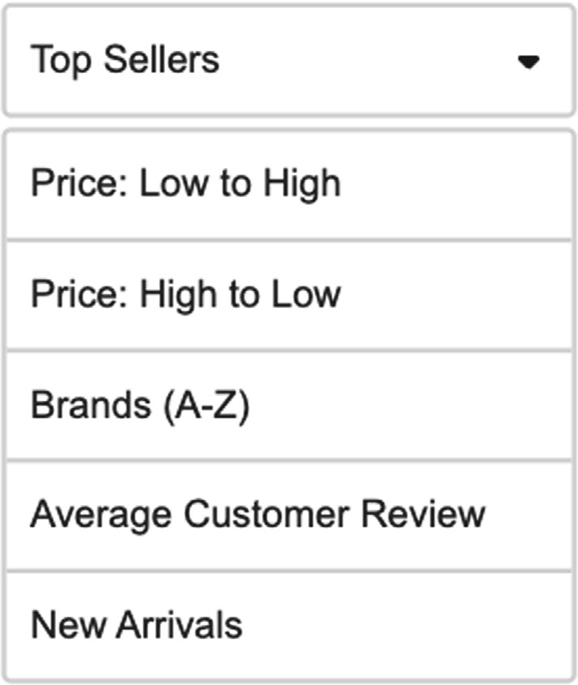

## Cues and scanning

- **Information scent:** cues predicting where useful information lies.
- Meaningful headings, labels, and summaries guide choices.
- Front-load distinctive words for people who scan.
- **Social media:** Use specific activity names instead of vague campaign link labels.

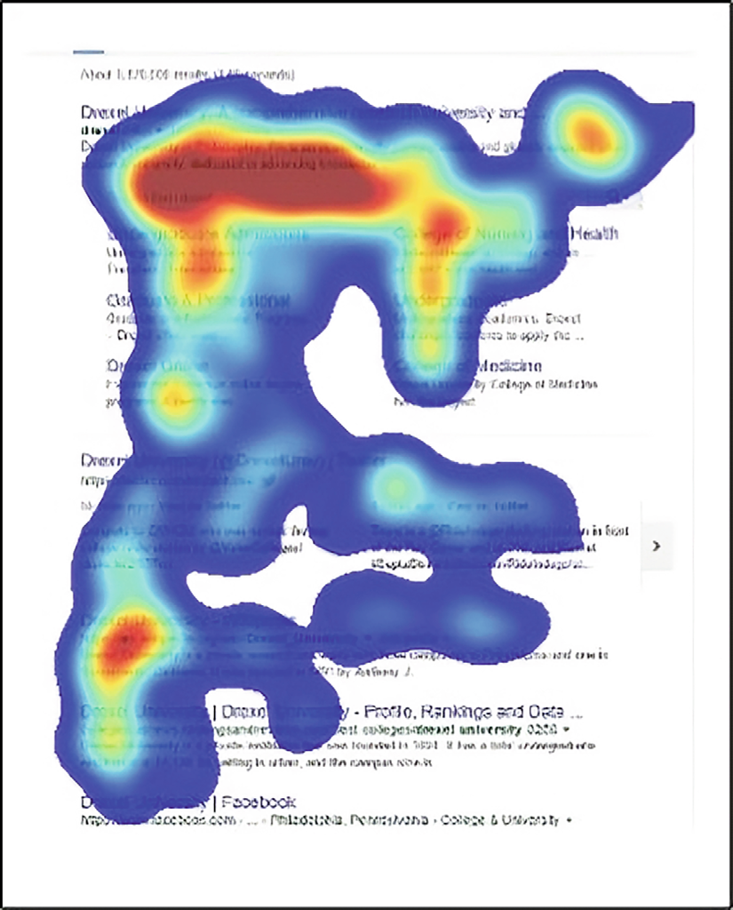

## Choices and actions

- **Hick:** more simple alternatives can slow decisions.
- **Fitts:** larger, nearer targets are quicker to select.
- Group routine options into meaningful categories.
- **Social media:** Make the application call to action clear in LinkedIn posts.

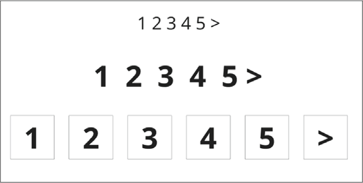

# Chapter 7

Interaction Design and Design Patterns

- `How is this implemented in client organization?`

## Interaction design principles

- Make possible actions visible through familiar cues.
- Reduce typing with useful defaults and typeahead.
- Prevent mistakes with clear instructions and valid choices.
- **Social media:** Make recruitment links recognizable and destination expectations clear.

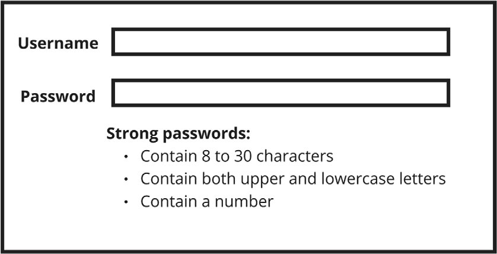

## Design patterns and workflows

- Reuse familiar solutions for recurring interaction problems.
- Hubs support independent tasks around a central view.
- Wizards guide dependent tasks through ordered steps.
- **Intranet:** Use a consistent onboarding sequence with clear next steps.

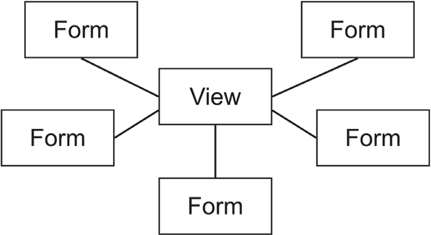

## Responsive and mobile design

- Adapt layouts to screen size with responsive grids.
- Prioritize essential content and frequent tasks.
- Minimize text entry with selections and helpful defaults.
- **Social media:** Check that campaign posts and linked content work on phones.

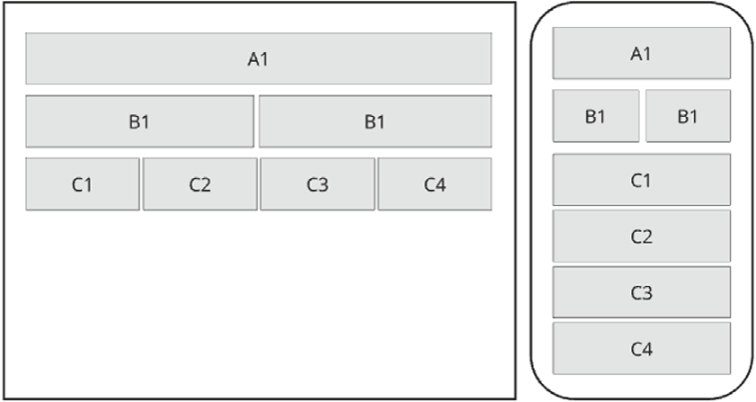